# Undergraduate Vacancy Rate

Author

Vinicius Hiago e Silva Geronimo

Published

June 15, 2025

## Higher Education Data

Brazilian higher education data at the course level was obtained from the 2023 Higher Education Census, from INEP, via the Base dos Dados organization’s datalake. The analysis focuses only on public institutions and undergraduate courses.

```r
# Set the billing ID
basedosdados::set_billing_id('vinicius-projetos-r')

# Query to download dictionary
dic_query = "SELECT * FROM `basedosdados.br_inep_censo_educacao_superior.dicionario`"

census_dic = basedosdados::read_sql(dic_query)


# Query to download higher education data
census_query = paste("
SELECT
  sigla_uf, id_municipio, tipo_grau_academico, tipo_organizacao_administrativa,      nome_area_detalhada, nome_area_geral, quantidade_vagas, quantidade_ingressantes
FROM
  `basedosdados.br_inep_censo_educacao_superior.curso`
WHERE
  ano = 2023 AND tipo_nivel_academico = '1' AND rede = '1' AND sigla_uf IS NOT NULL   AND nome_area_detalhada IS NOT NULL
", sep="")

census_base = as.data.frame(basedosdados::read_sql(
    query = gsub("\\s+", " ", census_query)))

for (col in c(7:8)){
  census_base[,col] = as.numeric(census_base[,col])
}
```

## Data Processing and Geolocation

The vacancy rate was calculated by **(number of vacancies - number of admitted students) / number of vacancies**.

The first processing step was to define the maximum number of admitted students in a course at an institution as the total number of vacancies for that course. This is necessary because it is common to have courses with a higher number of admitted students than the total number of vacancies offered in the database, perhaps due to filling errors by institutions caused by confusion in adopted concepts, which would hinder our analysis.

The second processing step was to remove the ‘Federal Institute of Education, Science and Technology of Mato Grosso’ from our database, as it represented an outlier in the data.

To locate the mesoregion where the institution is installed, a spreadsheet from the NEREUS group was used to match municipalities with mesoregions. The boundaries of Brazilian mesoregions were obtained through the `geobr` package.

```r
# Normalize columns
norm_categoria = census_dic %>%
  filter(nome_coluna == 'tipo_categoria_administrativa') %>%
  select(chave, valor) %>%
  deframe()

norm_grau = census_dic %>%
  filter(nome_coluna == 'tipo_grau_academico') %>%
  select(chave, valor) %>%
  deframe()

census_base = census_base %>%
  mutate(tipo_grau_academico = recode(tipo_grau_academico, !!!norm_grau),
         tipo_organizacao_administrativa = recode(tipo_organizacao_administrativa, !!!norm_categoria))


# Define the maximum number of admitted students
census_base = census_base %>%
  mutate(qtd_vagas_tratada = ifelse(quantidade_vagas == 0, NA, quantidade_vagas),
         qtd_ingressos_tratado = ifelse(quantidade_ingressantes > qtd_vagas_tratada, qtd_vagas_tratada, quantidade_ingressantes))

# Remove institution
census_base = census_base %>%
  filter(qtd_vagas_tratada < 1000 | qtd_vagas_tratada == 1126)
```

```r
# Get mesoregions's boundaries
meso_boundary = read_meso_region(year=2020) %>%
  select(name_meso, geom) %>%
  mutate(name_meso = str_to_lower(stri_trans_general(name_meso, "latin-ascii")))

# Get match between municipatilies and mesoregions
join = read_xlsx('regioes_geo.xlsx') %>%
  select(8,12) %>%
  rename(codigo = `Código Município Completo`,
         meso = `Nome_Mesorregião`) %>%
  mutate(meso = str_to_lower(stri_trans_general(meso, "latin-ascii")))

# Join tables
final_base = left_join(census_base, join, by = c('id_municipio' = 'codigo'))
final_base = left_join(final_base, meso_boundary, by = c('meso'='name_meso')) %>% st_as_sf()
```

```r
# Create table grouping by mesoregions
t = final_base %>%
  group_by(meso) %>%
  summarise(ingressos = sum(qtd_ingressos_tratado),
            vagas = sum(qtd_vagas_tratada)) %>%
  mutate(taxa = (vagas - ingressos) / vagas)
```

## Graphs

From the map below, it is possible to perceive that the undergraduate vacancy rate has a spatial heterogeneity. More specifically, the North and Northeast regions show a higher occupation of offered vacancies, while the Center-South of Brazil presents a higher vacancy rate, with the exception of São Paulo and Paraná, where they apparently also show low vacancy rates.

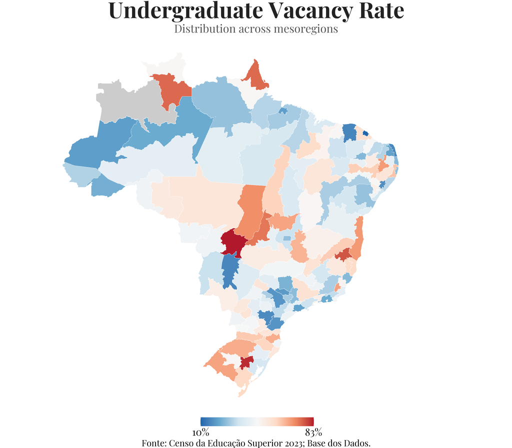

```r
max_val <- max(t$taxa, na.rm = TRUE)
min_val <- min(t$taxa, na.rm = TRUE)

ggplot() +
  geom_sf(data = meso_boundary, fill = 'grey80', color = "white", linewidth = 0.5) +
  geom_sf(data = t, aes(fill=taxa), color = "white", linewidth = 0.2) +
  scale_fill_distiller(
    name = "",
    palette = "RdBu",
    direction = -1,
    na.value = "grey",
    labels = percent,
    limits = c(min_val, max_val),
    breaks = c(min_val, max_val)) +
  labs(
    title = "Undergraduate Vacancy Rate",
    subtitle = "Distribution across mesoregions",
    caption = "Fonte: Censo da Educação Superior 2023; Base dos Dados."
  ) +
  theme_void() +
  theme(
    plot.title = element_text(family = "pf", size = 100, face = "bold", color = "#222222", hjust = 0.5),
    plot.subtitle = element_text(family = "pf", size = 50, color = "#555555", hjust = 0.5),
    legend.text = element_text(family = "pf", size = 45),
    plot.caption = element_text(family = "pf", size = 40, hjust = 0.5),
    legend.position = 'bottom',
    legend.key.width = unit(1.8, "cm"),
    legend.key.size= unit(0.7, "cm")
  )
```

Seeking to deepen the work, a study was conducted on which bachelor’s and licentiate degree courses presented the highest and lowest vacancy rates in Brazil. Courses with few classes and vacancies offered in Brazil were disregarded, such as, for example, Education Science, limiting the analysis to larger courses. A greater presence of Data and Software courses is observed among those with lower vacancy rates, and Engineering courses among those with higher vacancy rates.

```r
ordered_data <- as.data.frame(final_base) %>%
  filter(!is.na(nome_area_detalhada),
         tipo_grau_academico %in% c('Bacharelado', 'Licenciatura'),
         !nome_area_detalhada %in% c('Medicina e terapia tradicional e complementar',
                                     'Finanças, bancos e seguros',
                                     'Ciência da educação',
                                     'Têxteis (vestuário, calçados e couro)',
                                     'Programas interdisciplinares abrangendo engenharia, produção e construção',
                                     'Formação de professores de educação infantil',
                                     'Programas interdisciplinares abrangendo ciências sociais, comunicação e informação',
                                     'Veículos a motor, construção naval, aeronáutica, ferroviária e metroviária')) %>%
  group_by(nome_area_detalhada) %>%
  summarise(vagas = sum(qtd_vagas_tratada, na.rm = TRUE),
            ingressos = sum(qtd_ingressos_tratado, na.rm = TRUE),
            taxa = (vagas - ingressos)/vagas,
            .groups = 'drop') %>%
  mutate(taxa_z = round((taxa - mean(taxa, na.rm = TRUE)) / sd(taxa, na.rm = TRUE),2)) %>%
  arrange(desc(taxa_z))


bottom_10 <- tail(ordered_data, 10)

top_10 <- head(ordered_data, 10)


top_bottom_20 <- bind_rows(top_10, bottom_10) %>%
  mutate(nome_area_detalhada = factor(nome_area_detalhada, levels = ordered_data$nome_area_detalhada)) %>%
  mutate(
    nome_area_curto = recode(nome_area_detalhada,
                             "Programas interdisciplinares abrangendo computação e Tecnologias da Informação e Comunicação (TIC)" = 'Desenvolvimento de Softw.',
                             "Soluções computacionais para domínios específicos"  = "Ciência de dados",
                             "Setor militar e de defesa" = "Ciências militares",
                             "Medicina" = "Medicina",
                             "Odontologia" = "Odontologia",
                             "Veterinária" = "Veterinária",
                             "Ciência da computação" = "Ciência da computação",
                             "Programas interdisciplinares abrangendo educação" = "Interdisciplina em educação",
                             "Silvicultura" = "Engenharia florestal",
                             "Física" = "Física",
                             "Matemática" = "Matemática",
                             "Programas interdisciplinares abrangendo artes e humanidades" = "Interdisciplina em humanidades",
                             "Processamento de alimentos" = "Engenharia de alimentos",
                             "Materiais" = "Engenharia de materiais",
                             "Pesca" = "Engenharia de pesca",
                             "Serviços de alimentação" = "Gastronomia",
                             "Produção de software" = "Engenharia de Softw.",
                             "Mineração e extração" = "Eng. de Minas e Petróleo"))
```

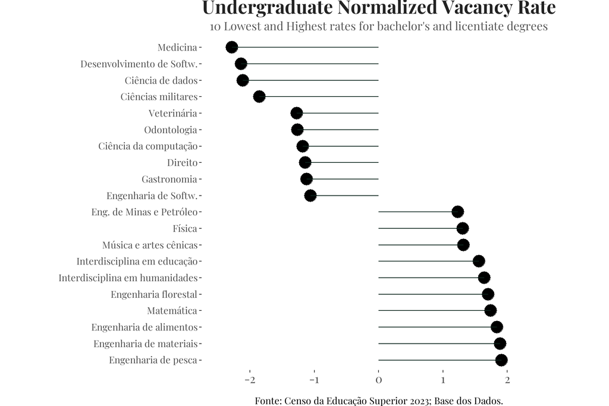

```r
ggplot(top_bottom_20, aes(x=nome_area_curto, y=taxa_z, label=taxa_z)) +
  geom_point(stat='identity', fill="#26735B", size=6)  +
  geom_segment(aes(y = 0,
                   x = nome_area_curto,
                   yend = taxa_z,
                   xend = nome_area_curto),
               color = "#0D261E") +
  labs(title="Undergraduate Normalized Vacancy Rate",
       subtitle="10 Lowest and Highest rates for bachelor's and licentiate degrees",
       x='',
       y='',
       caption = "Fonte: Censo da Educação Superior 2023; Base dos Dados."
  ) +
  ylim(-2.5, 2.5) +
  coord_flip() +
  theme(
     panel.background = element_rect(fill = "white", colour = NA),
    plot.background = element_rect(fill = "white", colour = NA),
    panel.grid.major = element_blank(),
    panel.grid.minor = element_blank(),

    text = element_text(family = "pf"),
    plot.title = element_text(size = 40, face = "bold", color = "#222222", hjust = 0.5),
    plot.margin = margin(r = 2, l = 2, unit = "cm"),
    plot.subtitle = element_text( size = 25, color = "#555555", hjust = 0.5),
    plot.caption = element_text(size = 20, hjust = 0.5),
    legend.position = 'none',
    axis.text.x = element_text(size = 25),
    axis.text.y = element_text(size = 20))
```

Finally, seeking to expand the analysis, a visualization was developed to better understand the misalignment between offered courses and regional demands.

In the graph below, it is noticeable that ICT, Health, and Business & Law courses have a high occupancy rate in practically all states. Courses classified as Exact Sciences, Education, and Agro & Veterinary are those with lower occupancy rates in several states.

#### This analysis is useful for contributing to the discussion of reviewing the distribution and relevance of courses offered in Brazil.

```r
# Griup by major area and state
regional_data <- as.data.frame(final_base) %>%
  filter(!is.na(nome_area_geral)) %>%
  group_by(nome_area_geral, sigla_uf) %>%
  summarise(vagas = sum(qtd_vagas_tratada, na.rm = TRUE),
            ingressos = sum(qtd_ingressos_tratado, na.rm = TRUE),
            taxa = (vagas - ingressos)/vagas)

# Get the unique values
unicos = unique(regional_data$nome_area_geral)

# Rename major areas
regional_data = regional_data %>%
  mutate(nome_curto =
    case_when(
      nome_area_geral == 'Agricultura, silvicultura, pesca e veterinária' ~ 'Agro e Veterinária',
      nome_area_geral == 'Ciências naturais, matemática e estatística'~'Ciências exatas',
      nome_area_geral == 'Ciências sociais, comunicação e informação'~'Sociais e comunicação',
      nome_area_geral == 'Computação e Tecnologias da Informação e Comunicação (TIC)'~'TIC',
      nome_area_geral == 'Engenharia, produção e construção'~'Engenharias',
      nome_area_geral == 'Negócios, administração e direito'~'Negócios e Direito',
      nome_area_geral == 'Saúde e bem-estar'~'Saúde',
      nome_area_geral == 'Artes e humanidades'~'Artes e humanidades',
      nome_area_geral == 'Educação'~'Educação',
      nome_area_geral == 'Serviços'~'Serviços',
      nome_area_geral == 'Programas básicos'~'Programas básicos'
    )
  )
```

```r
# Create table to get regions
dados_estados <- data.frame(
  sigla_uf = c("AC", "AL", "AM", "AP", "BA", "CE", "DF", "ES", "GO", "MA",
                   "MG", "MS", "MT", "PA", "PB", "PE", "PI", "PR", "RJ", "RN",
                   "RO", "RR", "RS", "SC", "SE", "SP", "TO"),
  regiao = c("Norte", "Nordeste", "Norte", "Norte", "Nordeste", "Nordeste", "Centro-Oeste", "Sudeste", "Centro-Oeste", "Nordeste",
             "Sudeste", "Centro-Oeste", "Centro-Oeste", "Norte", "Nordeste", "Nordeste", "Nordeste", "Sul", "Sudeste", "Nordeste",
             "Norte", "Norte", "Sul", "Sul", "Nordeste", "Sudeste", "Norte")
)


ordem_regioes <- c("Norte", "Nordeste", "Sudeste", "Sul", "Centro-Oeste")

# Sort states
dados_ordenados <- dados_estados %>%
  mutate(regiao = factor(regiao, levels = ordem_regioes)) %>%
  arrange(regiao, sigla_uf) %>%
  mutate(sigla_uf = factor(sigla_uf, levels = unique(sigla_uf)))

regional_data = left_join(regional_data,
                          dados_ordenados) %>%
  arrange(regiao) %>%
  mutate(sigla_uf = fct_inorder(sigla_uf))
```

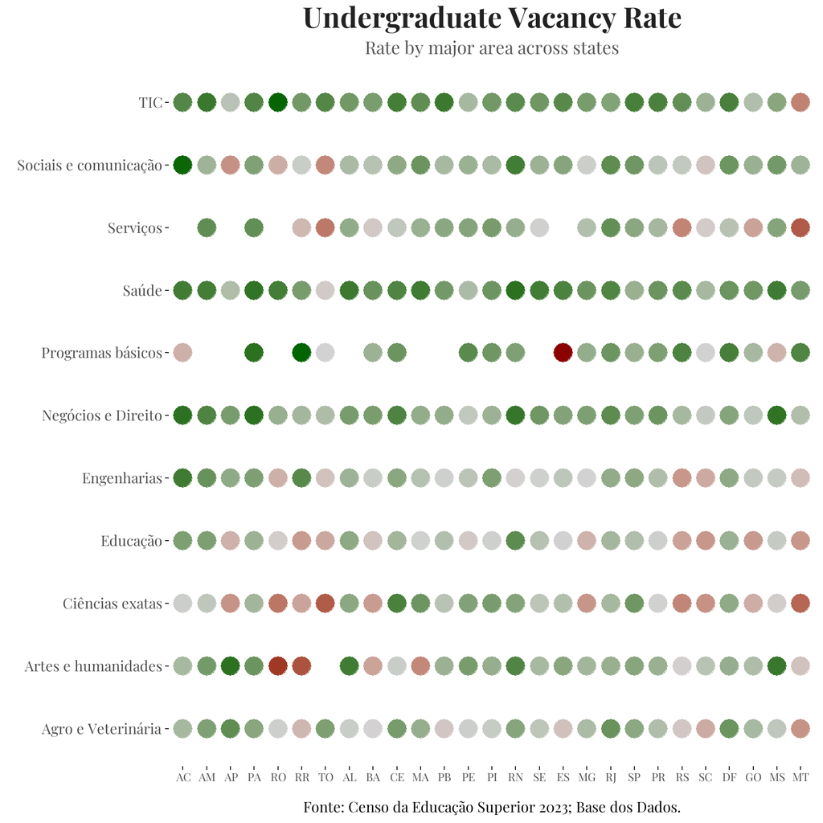

```r
ggplot(regional_data, aes(nome_curto, sigla_uf, color = taxa)) +
  geom_point(size = 6) +
  scale_color_gradient2(
    low = "darkgreen",
    mid = "lightgrey",
    high = "darkred",
    midpoint = 0.5)+ labs(title="Undergraduate Vacancy Rate",
       subtitle="Rate by major area across states",
       x='',
       y='',
       caption = "Fonte: Censo da Educação Superior 2023; Base dos Dados."
  ) +
  coord_flip() +
  theme(
     panel.background = element_rect(fill = "white", colour = NA),
    plot.background = element_rect(fill = "white", colour = NA),
    panel.grid.major = element_blank(),
    panel.grid.minor = element_blank(),
    text = element_text(family = "pf"),
    plot.title = element_text(size = 40, face = "bold", color = "#222222", hjust = 0.5),
    plot.subtitle = element_text( size = 25, color = "#555555", hjust = 0.5),
    plot.caption = element_text(size = 20, hjust = 0.5),
    legend.position = 'none',
    axis.text.x = element_text(size = 16),
    axis.text.y = element_text(size = 20))
```